# Module 4 Overview Assignment

Saif Elsaady

### Formatting

R script (3 Points) - You will receive 3 points for having a functioning .rmd file. This script must be used to answer the assigned questions. Include comments in the script as well.

## Question 1 (5 points)

### Part 1 (1 point)

Load the “HMF Complete Uncleaned.csv” file. This is a more complete version of the data you have been working with in this and previous sections. Note that there is missing data and you may have to adjust for this for some of your calculations.

```r
df <- read.csv("HMF Complete Uncleaned.csv")
# Display the first few rows of the dataset
head(df)
```

```
##   uniqueid       band initialcapture bandsize      date year  time  net  sex
## 1        5  58-159034              n     <NA> 6/26/1961 1961 18:40  61B    M
## 2        5  58-159034              n     <NA> 6/12/1961 1961 13:40  62B    M
## 3     1448 101-110513              y     <NA> 5/27/1964 1964 17:50 Nest <NA>
## 4     1449 101-110512              y     <NA> 5/27/1964 1964 17:50 Nest <NA>
## 5     1454 101-110515              y     <NA> 5/27/1964 1964 17:50 Nest <NA>
## 6     1455 101-110514              y     <NA> 5/27/1964 1964 17:50 Nest <NA>
##   age weight      species speciesc        habitat    food nesting
## 1 AHY     NA  Wood Thrush     WOTH         forest insects    tree
## 2 AHY     NA  Wood Thrush     WOTH         forest insects    tree
## 3   N     NA Song Sparrow     SOSP open woodlands insects   shrub
## 4   N     NA Song Sparrow     SOSP open woodlands insects   shrub
## 5   N     NA Song Sparrow     SOSP open woodlands insects   shrub
## 6   N     NA Song Sparrow     SOSP open woodlands insects   shrub
##            behav   wc wcr wcf broodp fatc   cp notes
## 1 ground forager 11.0  NA  NA   <NA>    0 <NA>  <NA>
## 2 ground forager 11.0  NA  NA   <NA>    0 <NA>  <NA>
## 3 ground forager 29.5  NA  NA      n    0    n  <NA>
## 4 ground forager 30.0  NA  NA      n    0    n  <NA>
## 5 ground forager 31.0  NA  NA      n    0    n  <NA>
## 6 ground forager 31.5  NA  NA      n    0    n  <NA>
```

```r
# Get a summary of the dataset to check for missing values
summary(df)
```

```
##     uniqueid          band           initialcapture       bandsize
##  Min.   :   1.0   Length:4332        Length:4332        Length:4332
##  1st Qu.: 611.8   Class :character   Class :character   Class :character
##  Median :1248.0   Mode  :character   Mode  :character   Mode  :character
##  Mean   :1193.5
##  3rd Qu.:1766.0
##  Max.   :2454.0
##
##      date                year          time               net
##  Length:4332        Min.   :1960   Length:4332        Length:4332
##  Class :character   1st Qu.:1963   Class :character   Class :character
##  Mode  :character   Median :1964   Mode  :character   Mode  :character
##                     Mean   :1971
##                     3rd Qu.:1967
##                     Max.   :2015
##                     NA's   :1
##      sex                age                weight         species
##  Length:4332        Length:4332        Min.   :  4.20   Length:4332
##  Class :character   Class :character   1st Qu.: 33.00   Class :character
##  Mode  :character   Mode  :character   Median : 35.30   Mode  :character
##                                        Mean   : 38.63
##                                        3rd Qu.: 41.70
##                                        Max.   :102.30
##                                        NA's   :3891
##    speciesc           habitat              food             nesting
##  Length:4332        Length:4332        Length:4332        Length:4332
##  Class :character   Class :character   Class :character   Class :character
##  Mode  :character   Mode  :character   Mode  :character   Mode  :character
##
##
##
##
##     behav                 wc              wcr              wcf
##  Length:4332        Min.   : 11.00   Min.   :  1.00   Min.   : 37.8
##  Class :character   1st Qu.: 83.50   1st Qu.: 85.00   1st Qu.: 87.0
##  Mode  :character   Median : 99.00   Median : 89.00   Median : 91.0
##                     Mean   : 98.56   Mean   : 93.12   Mean   : 95.2
##                     3rd Qu.:109.00   3rd Qu.:102.00   3rd Qu.:105.0
##                     Max.   :199.00   Max.   :150.00   Max.   :149.0
##                     NA's   :744      NA's   :3840     NA's   :3842
##     broodp              fatc                cp               notes
##  Length:4332        Length:4332        Length:4332        Length:4332
##  Class :character   Class :character   Class :character   Class :character
##  Mode  :character   Mode  :character   Mode  :character   Mode  :character
##
##
##
##
```

```r
# Count missing values in each column
colSums(is.na(df))
```

```
##       uniqueid           band initialcapture       bandsize           date
##              0              4              0           3648              0
##           year           time            net            sex            age
##              1             51             58            732             73
##         weight        species       speciesc        habitat           food
##           3891              0              1              0              0
##        nesting          behav             wc            wcr            wcf
##              0              0            744           3840           3842
##         broodp           fatc             cp          notes
##           1612            894           1854           4247
```

### Part 2 (2 points)

Calculate the mean bird weight for the data set. In this data, the weight roughly follows a Poisson distribution (note this is because we are looking at multiple species with different average weights). Using your mean weight,plot the Poisson density function for weight.

```r
mean_weight <- mean(df$weight, na.rm = TRUE)

# Print the mean weight
print(paste("Mean Bird Weight:", mean_weight))
```

```
## [1] "Mean Bird Weight: 38.6328798185941"
```

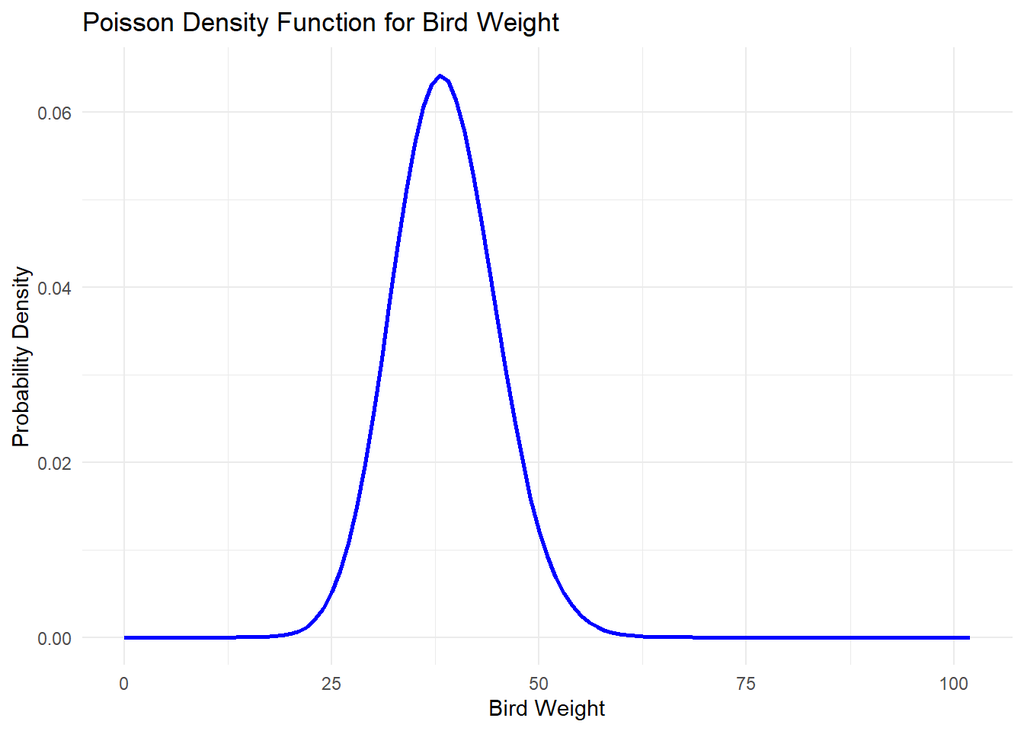

```r
# Define weight range for plotting
weight_range <- seq(0, max(df$weight, na.rm = TRUE), by = 1)

# Compute Poisson probability density for given mean
poisson_density <- dpois(weight_range, lambda = mean_weight)

# Plot the Poisson density function
ggplot(data = data.frame(weight_range, poisson_density), aes(x = weight_range, y = poisson_density)) +
  geom_line(color = "blue", size = 1) +
  labs(title = "Poisson Density Function for Bird Weight",
       x = "Bird Weight",
       y = "Probability Density") +
  theme_minimal()
```

### Part 3 (2 points)

In this data, bird weight is measured in grams. What is the probability that a randomly selected bird weighs less than 44 grams? What is the probability that a randomly selected bird weighs more than 35 grams?

#### Part 3 Answers

```r
# Calculate the mean bird weight
mean_weight <- mean(df$weight, na.rm = TRUE)

# Probability that a randomly selected bird weighs less than 44 grams
prob_less_44 <- ppois(44, lambda = mean_weight)

# Probability that a randomly selected bird weighs more than 35 grams
prob_more_35 <- 1 - ppois(35, lambda = mean_weight)

# Print results
print(paste("P(Weight < 44g) =", round(prob_less_44, 4)))
```

```
## [1] "P(Weight < 44g) = 0.8284"
```

```r
print(paste("P(Weight > 35g) =", round(prob_more_35, 4)))
```

```
## [1] "P(Weight > 35g) = 0.6857"
```

## Question 2 (12 points)

### Part 1 (2 Points)

Using R, subset the data into two time periods. One time period will be from 1960-1968. The other time period will be from 2011-2014. Name the the new dataframes “HMF_Historic_Data” and “HMF_Recent_Data” respectively. You can use either tidyverse or the subsetting function here

```r
# Convert year column to numeric (in case it's stored as character)
df$year <- as.numeric(df$year)

# Subset data for 1960-1968
HMF_Historic_Data <- df %>%
  filter(year >= 1960 & year <= 1968)

# Subset data for 2011-2014
HMF_Recent_Data <- df %>%
  filter(year >= 2011 & year <= 2014)

# Print first few rows of each dataset to verify
head(HMF_Historic_Data)
```

```
##   uniqueid       band initialcapture bandsize      date year  time  net  sex
## 1        5  58-159034              n     <NA> 6/26/1961 1961 18:40  61B    M
## 2        5  58-159034              n     <NA> 6/12/1961 1961 13:40  62B    M
## 3     1448 101-110513              y     <NA> 5/27/1964 1964 17:50 Nest <NA>
## 4     1449 101-110512              y     <NA> 5/27/1964 1964 17:50 Nest <NA>
## 5     1454 101-110515              y     <NA> 5/27/1964 1964 17:50 Nest <NA>
## 6     1455 101-110514              y     <NA> 5/27/1964 1964 17:50 Nest <NA>
##   age weight      species speciesc        habitat    food nesting
## 1 AHY     NA  Wood Thrush     WOTH         forest insects    tree
## 2 AHY     NA  Wood Thrush     WOTH         forest insects    tree
## 3   N     NA Song Sparrow     SOSP open woodlands insects   shrub
## 4   N     NA Song Sparrow     SOSP open woodlands insects   shrub
## 5   N     NA Song Sparrow     SOSP open woodlands insects   shrub
## 6   N     NA Song Sparrow     SOSP open woodlands insects   shrub
##            behav   wc wcr wcf broodp fatc   cp notes
## 1 ground forager 11.0  NA  NA   <NA>    0 <NA>  <NA>
## 2 ground forager 11.0  NA  NA   <NA>    0 <NA>  <NA>
## 3 ground forager 29.5  NA  NA      n    0    n  <NA>
## 4 ground forager 30.0  NA  NA      n    0    n  <NA>
## 5 ground forager 31.0  NA  NA      n    0    n  <NA>
## 6 ground forager 31.5  NA  NA      n    0    n  <NA>
```

```r
head(HMF_Recent_Data)
```

```
##   uniqueid      band initialcapture bandsize      date year  time net  sex age
## 1     1936 251091622              n     <NA> 6/15/2011 2011 10:50   6 <NA>  AD
## 2     1952 230191051              n     <NA> 6/27/2011 2011  7:10   9 <NA>  AD
## 3     1952 230191051              n     <NA> 7/24/2011 2011  7:30   9 <NA>  AD
## 4     1960 230191059              n     <NA>  8/5/2011 2011 10:15   2 <NA>  AD
## 5     1974 230191073              n     <NA> 7/17/2013 2013  6:30   6 <NA> AHY
## 6     2000 230191028              n     <NA>  6/4/2012 2012  9:30   9 <NA> AHY
##   weight             species speciesc        habitat    food nesting
## 1     NA Common Yellowthroat     COYE          scrub insects   shrub
## 2     NA        Gray Catbird     GRCA open woodlands insects   shrub
## 3     NA        Gray Catbird     GRCA open woodlands insects   shrub
## 4     NA        Gray Catbird     GRCA open woodlands insects   shrub
## 5   36.8        Gray Catbird     GRCA open woodlands insects   shrub
## 6   35.1        Gray Catbird     GRCA open woodlands insects   shrub
##             behav wc wcr wcf broodp fatc   cp notes
## 1 foliage gleaner NA  NA  NA   <NA> <NA> <NA>  <NA>
## 2  ground forager NA  NA  NA   <NA> <NA> <NA>  <NA>
## 3  ground forager NA  NA  NA   <NA> <NA> <NA>  <NA>
## 4  ground forager NA  NA  NA   <NA> <NA> <NA>  <NA>
## 5  ground forager NA  90  91   <NA> <NA> <NA>  <NA>
## 6  ground forager NA  90  94   <NA> <NA> <NA>  <NA>
```

```r
# Check number of observations in each subset
print(paste("Historic Data Count:", nrow(HMF_Historic_Data)))
```

```
## [1] "Historic Data Count: 3701"
```

```r
print(paste("Recent Data Count:", nrow(HMF_Recent_Data)))
```

```
## [1] "Recent Data Count: 354"
```

### Part 2 (2 Points)

Using the two data frames, create two additional data frames that calculate the number of captures per year. Name the first “Historic_Captures_Per_Year” and the second “Recent_Captures_Per_Year”. Note: each row represents a unique capture, so the total number of rows or observations per year represents the total number of captures.*Hint - using the group_by() and summarise() functions will be very useful here. Remember n() can be used to count the number of observations when used in the summarise command. Example summarise(count = n())*

```r
# Calculate number of captures per year for Historic Data
Historic_Captures_Per_Year <- HMF_Historic_Data %>%
  group_by(year) %>%
  summarise(count = n())

# Calculate number of captures per year for Recent Data
Recent_Captures_Per_Year <- HMF_Recent_Data %>%
  group_by(year) %>%
  summarise(count = n())

# Print the results to check
print(Historic_Captures_Per_Year)
```

```
## # A tibble: 9 × 2
##    year count
##   <dbl> <int>
## 1  1960   378
## 2  1961   190
## 3  1962   234
## 4  1963   642
## 5  1964   900
## 6  1965   196
## 7  1966   380
## 8  1967   466
## 9  1968   315
```

```r
print(Recent_Captures_Per_Year)
```

```
## # A tibble: 4 × 2
##    year count
##   <dbl> <int>
## 1  2011    98
## 2  2012    97
## 3  2013   101
## 4  2014    58
```

### Part 3 (2 Points)

Test to see if the number of captures/observations per year is normally distributed for each dataframe. For each data frame, produce one visualization test and one statistical test.

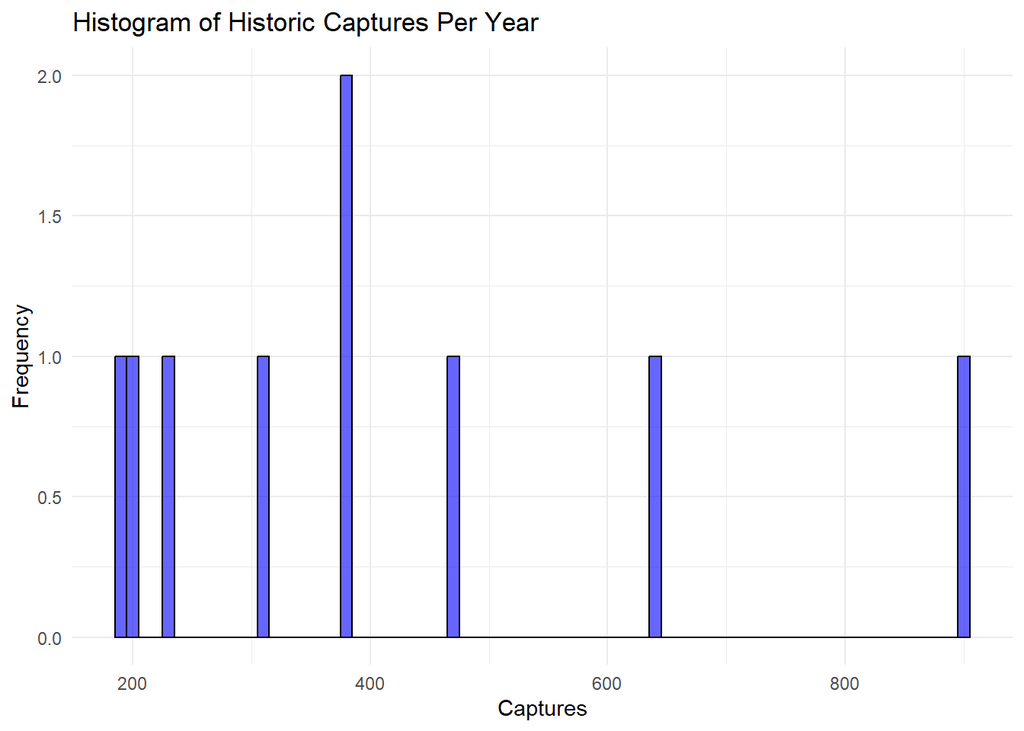

```r
# Visualization Test: Histogram and QQ Plot for Historic Data
ggplot(Historic_Captures_Per_Year, aes(x = count)) +
  geom_histogram(binwidth = 10, fill = "blue", alpha = 0.6, color = "black") +
  labs(title = "Histogram of Historic Captures Per Year", x = "Captures", y = "Frequency") +
  theme_minimal()
```

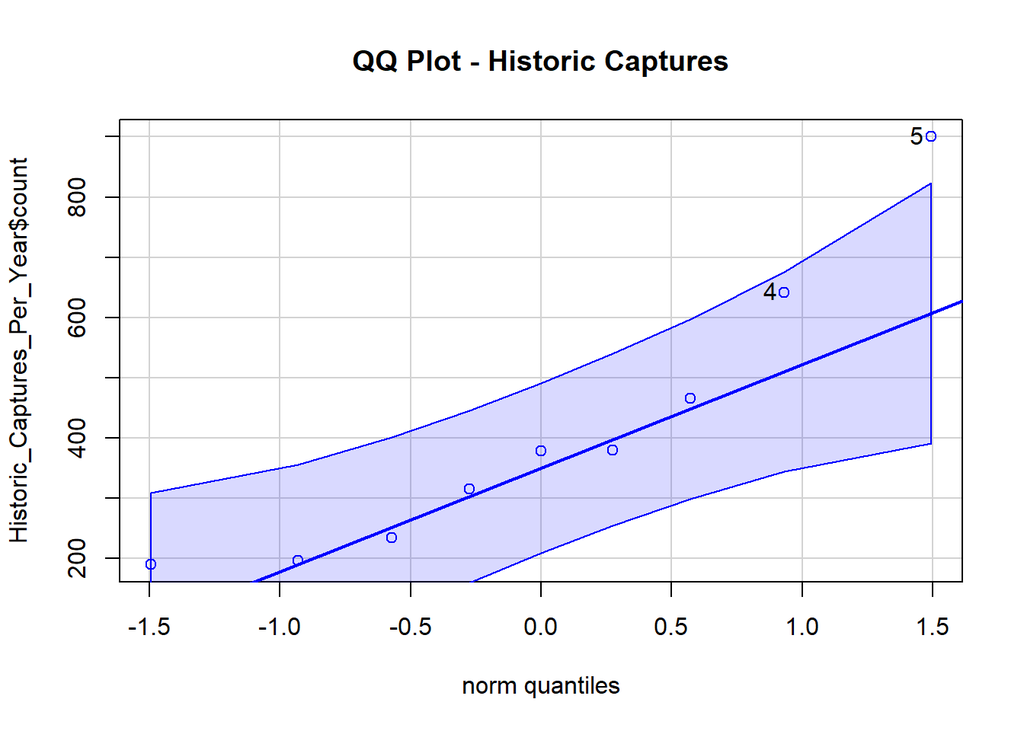

```
## [1] 5 4
```

```r
qqPlot(Historic_Captures_Per_Year$count, main = "QQ Plot - Historic Captures", col = "blue")
```

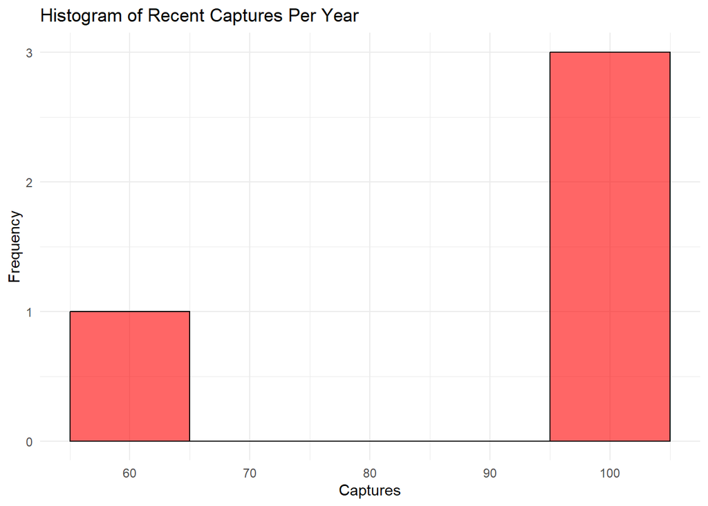

```r
# Visualization Test: Histogram and QQ Plot for Recent Data
ggplot(Recent_Captures_Per_Year, aes(x = count)) +
  geom_histogram(binwidth = 10, fill = "red", alpha = 0.6, color = "black") +
  labs(title = "Histogram of Recent Captures Per Year", x = "Captures", y = "Frequency") +
  theme_minimal()
```

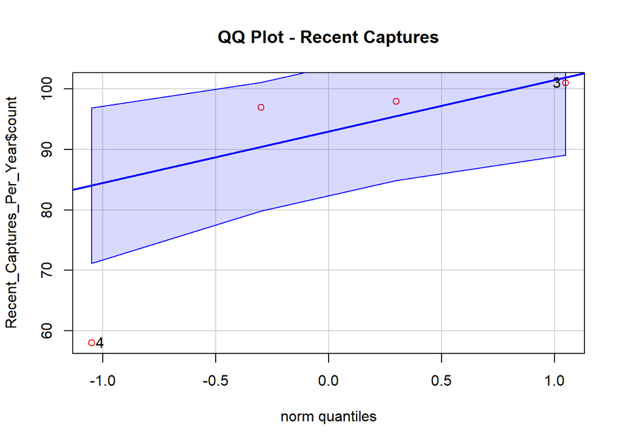

```
## [1] 4 3
```

```r
qqPlot(Recent_Captures_Per_Year$count, main = "QQ Plot - Recent Captures", col = "red")
```

```r
# Statistical Test: Shapiro-Wilk Test for Normality
shapiro_test_historic <- shapiro.test(Historic_Captures_Per_Year$count)
shapiro_test_recent <- shapiro.test(Recent_Captures_Per_Year$count)

# Print Results
print(shapiro_test_historic)
```

```
##
##  Shapiro-Wilk normality test
##
## data:  Historic_Captures_Per_Year$count
## W = 0.87242, p-value = 0.1305
```

```r
print(shapiro_test_recent)
```

```
##
##  Shapiro-Wilk normality test
##
## data:  Recent_Captures_Per_Year$count
## W = 0.70713, p-value = 0.01401
```

### Part 3.1 (1 Point)

In 2014 and 2015, sampling effort was only half of that in 2011, 2012, and 2013. To adjust for this, multiply the capture records for 2014 and 2015 by 2 (note that this is a very rough approximation of how to actually adjust for differences in trap effort). Now check to see if the recent data is normally distributed for captures by year. Hint: you can easily double the value in a specific cell in a data frame as follows “example_data[x,y]<-example_data[x,y]*2”

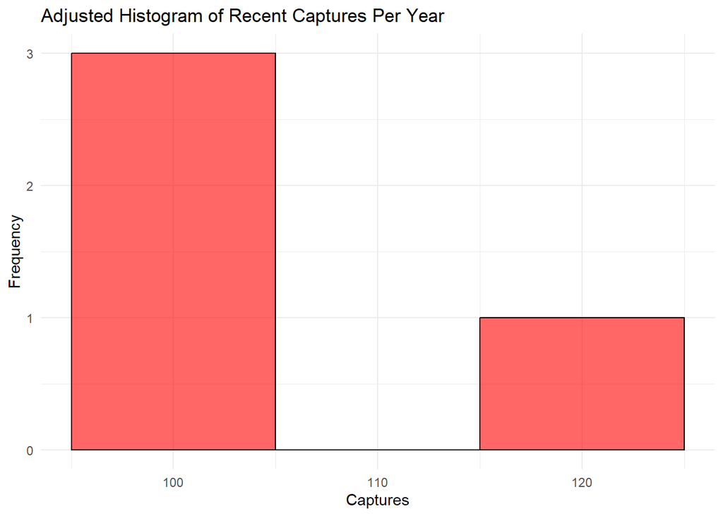

```r
# Adjust capture records for 2014 and 2015 by multiplying by 2
Recent_Captures_Per_Year$count[Recent_Captures_Per_Year$year %in% c(2014, 2015)] <-
  Recent_Captures_Per_Year$count[Recent_Captures_Per_Year$year %in% c(2014, 2015)] * 2

# Visualization: Histogram and QQ Plot
ggplot(Recent_Captures_Per_Year, aes(x = count)) +
  geom_histogram(binwidth = 10, fill = "red", alpha = 0.6, color = "black") +
  labs(title = "Adjusted Histogram of Recent Captures Per Year", x = "Captures", y = "Frequency") +
  theme_minimal()
```

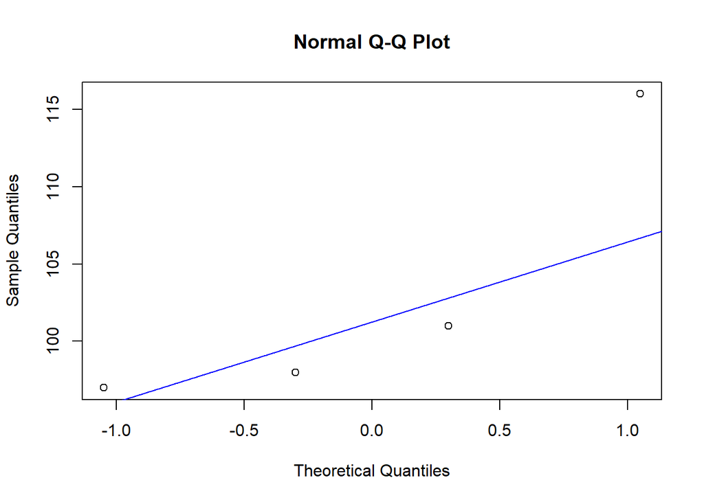

```r
qqnorm(Recent_Captures_Per_Year$count)
qqline(Recent_Captures_Per_Year$count, col = "blue")
```

```r
# Statistical Test: Shapiro-Wilk Normality Test
shapiro_test_adjusted <- shapiro.test(Recent_Captures_Per_Year$count)

# Print results
print(shapiro_test_adjusted)
```

```
##
##  Shapiro-Wilk normality test
##
## data:  Recent_Captures_Per_Year$count
## W = 0.78544, p-value = 0.07857
```

### Part 4 (2 Points)

Conduct a linear regression to investigate whether or not their is a statistical relationship between number of captures and year for the historic and recent time periods. For each time period, is there a relationship? How do you know?

#### Part 4 Answer Here

```r
# Linear regression for Historic Data
historic_lm <- lm(count ~ year, data = Historic_Captures_Per_Year)

# Summary of regression results for Historic Data
summary(historic_lm)
```

```
##
## Call:
## lm(formula = count ~ year, data = Historic_Captures_Per_Year)
##
## Residuals:
##     Min      1Q  Median      3Q     Max
## -222.26 -163.16  -45.29   33.68  488.78
##
## Coefficients:
##               Estimate Std. Error t value Pr(>|t|)
## (Intercept) -13402.244  62856.784  -0.213    0.837
## year             7.033     32.004   0.220    0.832
##
## Residual standard error: 247.9 on 7 degrees of freedom
## Multiple R-squared:  0.006852,   Adjusted R-squared:  -0.135
## F-statistic: 0.04829 on 1 and 7 DF,  p-value: 0.8323
```

```r
# Linear regression for Recent Data
recent_lm <- lm(count ~ year, data = Recent_Captures_Per_Year)

# Summary of regression results for Recent Data
summary(recent_lm)
```

```
##
## Call:
## lm(formula = count ~ year, data = Recent_Captures_Per_Year)
##
## Residuals:
##    1    2    3    4
##  3.7 -3.1 -4.9  4.3
##
## Coefficients:
##               Estimate Std. Error t value Pr(>|t|)
## (Intercept) -11569.500   5162.367  -2.241    0.154
## year             5.800      2.565   2.261    0.152
##
## Residual standard error: 5.736 on 2 degrees of freedom
## Multiple R-squared:  0.7188, Adjusted R-squared:  0.5782
## F-statistic: 5.112 on 1 and 2 DF,  p-value: 0.1522
```

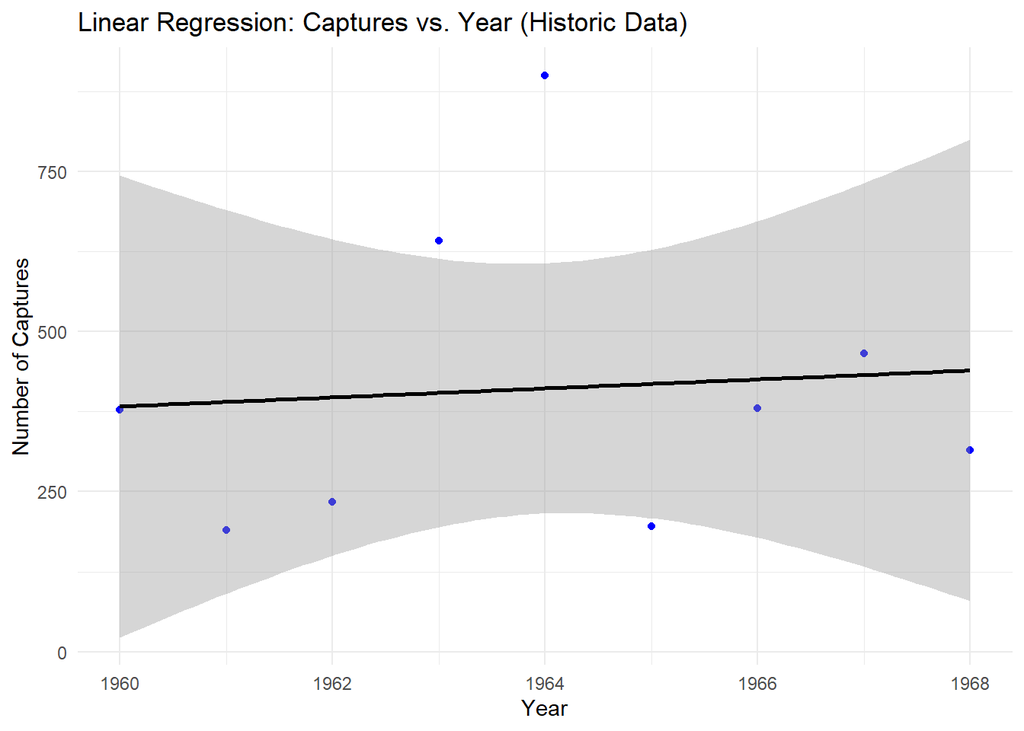

```r
# Visualization: Scatterplot with regression line for Historic Data
ggplot(Historic_Captures_Per_Year, aes(x = year, y = count)) +
  geom_point(color = "blue") +
  geom_smooth(method = "lm", se = TRUE, color = "black") +
  labs(title = "Linear Regression: Captures vs. Year (Historic Data)",
       x = "Year", y = "Number of Captures") +
  theme_minimal()
```

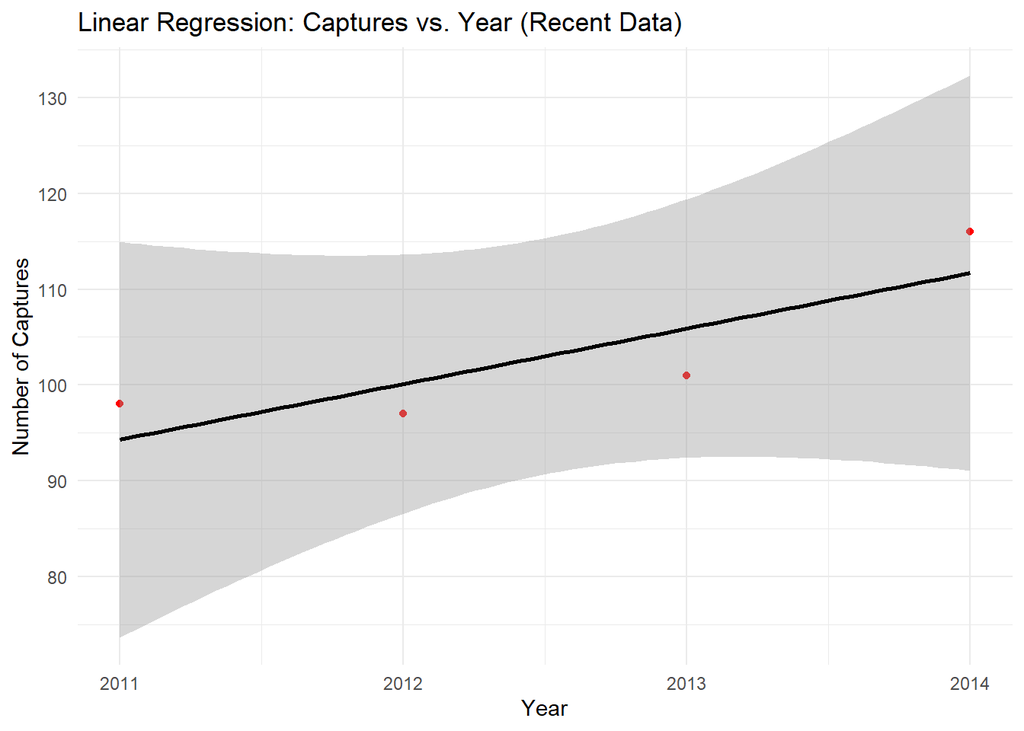

```r
# Visualization: Scatterplot with regression line for Recent Data
ggplot(Recent_Captures_Per_Year, aes(x = year, y = count)) +
  geom_point(color = "red") +
  geom_smooth(method = "lm", se = TRUE, color = "black") +
  labs(title = "Linear Regression: Captures vs. Year (Recent Data)",
       x = "Year", y = "Number of Captures") +
  theme_minimal()
```

### Part 5 (3 Points)

We are interested in knowing if the overall abundance of species is different between the historic and recent time periods. Conduct a test which compares the abundances between the Historic_Captures_Per_Year and the Recent_Captures_Per_Year dataframes. Are the abundances between these two time periods different? Use a boxplot to visualize this data

#### Part 5 Answer Here

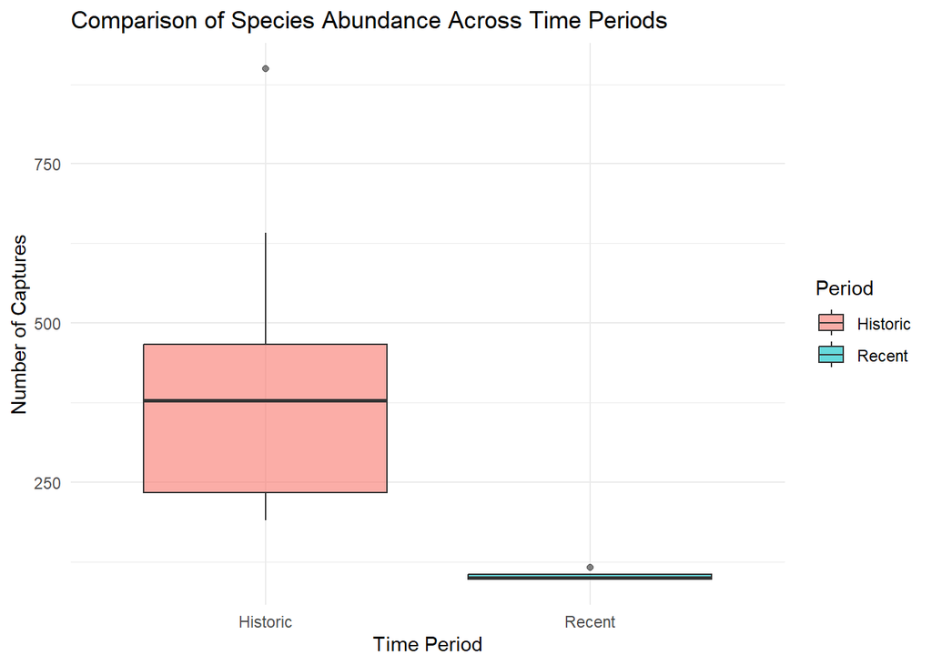

```r
# Add a time period label to each dataset
Historic_Captures_Per_Year$Period <- "Historic"
Recent_Captures_Per_Year$Period <- "Recent"

# Combine the two datasets
combined_data <- rbind(Historic_Captures_Per_Year, Recent_Captures_Per_Year)

# Boxplot to visualize abundance differences
ggplot(combined_data, aes(x = Period, y = count, fill = Period)) +
  geom_boxplot(alpha = 0.6) +
  labs(title = "Comparison of Species Abundance Across Time Periods",
       x = "Time Period", y = "Number of Captures") +
  theme_minimal()
```

```r
# Statistical Test: Wilcoxon Rank-Sum Test (Non-parametric alternative to t-test)
abundance_test <- wilcox.test(count ~ Period, data = combined_data, exact = FALSE)

# Print test results
print(abundance_test)
```

```
##
##  Wilcoxon rank sum test with continuity correction
##
## data:  count by Period
## W = 36, p-value = 0.006928
## alternative hypothesis: true location shift is not equal to 0
```

#### Question 3

### Part 1 (2 Points)

We want to know if, broadly speaking, functional traits vary by habitat. Create a data frame that includes the mean, median, and standard deviation for species wing cord length (“wc” in the dataframe) for species that live in forests (forest), grasslands (grassland), open woodlands (open woodlands) and scrub (scrub). *Once again, think about group_by() and summarise(). You will also need to filter so you only include the 4 groups of interest*

**Also note, drop levels will get rid of empty categories in your data frame. After you subset your data, you may see that your data still includes habitats that are not of interest even though there are 0 records for these habitats. droplevels() will fix this. Use droplevels as so: exampledata<-droplevels(exampledata)**

```r
# Filter the dataset for only the four habitat types of interest
filtered_data <- df %>%
  filter(habitat %in% c("forest", "grassland", "open woodlands", "scrub"))

# Remove empty categories from the dataset
filtered_data <- droplevels(filtered_data)

# Calculate mean, median, and standard deviation for wing cord length ("wc") by habitat type
wc_stats <- filtered_data %>%
  group_by(habitat) %>%
  summarise(
    mean_wc = mean(wc, na.rm = TRUE),
    median_wc = median(wc, na.rm = TRUE),
    sd_wc = sd(wc, na.rm = TRUE)
  )

# Print results
print(wc_stats)
```

```
## # A tibble: 4 × 4
##   habitat        mean_wc median_wc sd_wc
##   <chr>            <dbl>     <dbl> <dbl>
## 1 forest            97.1     104    17.2
## 2 grassland         97.8      98.8  12.3
## 3 open woodlands   104.       93.5  25.8
## 4 scrub             84.2      84    11.0
```

### Part 2 (3 Points)

Run a test(s) to determine if wing cord length differs between habitat types. How does wing cord length differ between these four habitats? Create a boxplot that shows wing cord (measured in cm) for each habitat type.

#### Answer Here

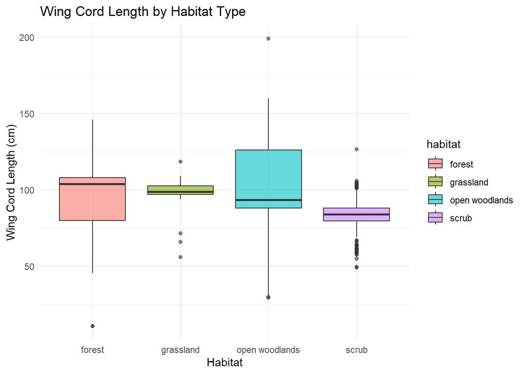

```r
# Boxplot to visualize wing cord length across habitats
ggplot(filtered_data, aes(x = habitat, y = wc, fill = habitat)) +
  geom_boxplot(alpha = 0.6) +
  labs(title = "Wing Cord Length by Habitat Type",
       x = "Habitat", y = "Wing Cord Length (cm)") +
  theme_minimal()
```

```r
# Check for normality assumption using Shapiro-Wilk test
shapiro_test <- filtered_data %>%
  group_by(habitat) %>%
  summarise(p_value = shapiro.test(wc)$p.value)

print(shapiro_test)
```

```
## # A tibble: 4 × 2
##   habitat         p_value
##   <chr>             <dbl>
## 1 forest         4.03e-29
## 2 grassland      6.23e- 6
## 3 open woodlands 4.48e-22
## 4 scrub          6.67e- 9
```

```r
# If normality assumption holds (p > 0.05 for all groups), run ANOVA
if (all(shapiro_test$p_value > 0.05)) {
  anova_model <- aov(wc ~ habitat, data = filtered_data)
  anova_result <- summary(anova_model)
  print(anova_result)
} else {
  # If data is not normally distributed, run Kruskal-Wallis test
  kruskal_result <- kruskal.test(wc ~ habitat, data = filtered_data)
  print(kruskal_result)
}
```

```
##
##  Kruskal-Wallis rank sum test
##
## data:  wc by habitat
## Kruskal-Wallis chi-squared = 192.66, df = 3, p-value < 2.2e-16
```